# Python+

### Krzysztof Lewiński & Mateusz Kurek

## Agenda

- Introduction to Python
- Syntax
- Basic types and data structures
- Advanced usage (tips & tricks)
- Built-in functions & Standard library
- Modules, packages, virtualenv
- IPython
- PyPy
- NumPy
- scikit-learn
- Django
- More tips & tricks

## Introduction to Python

### History

- Creator: **Guidio van Rossum**
- When: 1991
- Current version: 2.7.9 / 3.4.2

[figure not shown]

### Python philosophy

- emphasizes code readability
- dynamic type system (but strong!)
- multi-paradigm:
  - object-oriented
  - imperative
  - functional (partialy)
  - aspect (parialy)
- duck typing
- excellent documentation and community

Python probably has the reputation of supporting functional programming based on the inclusion of lambda, map, filter, and reduce in the language, but in my eyes these are just **syntactic sugar**, and not the fundamental building blocks that they are in functional languages.

#### PEP 20 (The Zen of Python)

- Beautiful is better than ugly
- Explicit is better than implicit
- Simple is better than complex
- Complex is better than complicated
- Readibility counts

...

```python
import this
```

```
The Zen of Python, by Tim Peters

Beautiful is better than ugly.
Explicit is better than implicit.
Simple is better than complex.
Complex is better than complicated.
Flat is better than nested.
Sparse is better than dense.
Readability counts.
Special cases aren't special enough to break the rules.
Although practicality beats purity.
Errors should never pass silently.
Unless explicitly silenced.
In the face of ambiguity, refuse the temptation to guess.
There should be one-- and preferably only one --obvious way to do it.
Although that way may not be obvious at first unless you're Dutch.
Now is better than never.
Although never is often better than *right* now.
If the implementation is hard to explain, it's a bad idea.
If the implementation is easy to explain, it may be a good idea.
Namespaces are one honking great idea -- let's do more of those!
```

### Python vs C/C++

| Python | C/C++ |
| --- | --- |
| Easy and legible | 775 pages of language specification |
| Interpreted | Compiled |
| Garbage Collector | Lack of GC |
| Dynamically typed | Statically typed |

### Syntax

- uses whitespace to delimit program blocks (Off-side rule)
- everything is an object (variable, function, instance, even class)
- files with .py extensions

```python
print("Hello world")
```

```
Hello world
```

```python
a = 10  # int
b = 'abc'  # str
c = d = None  # empty value - equivalent of NULL, NIL etc
print(a, b, c, d)
```

```
(10, 'abc', None, None)
```

```python
# example comment
```

##### Strings

```python
a = "abc"
b = 'def'
c = """
multi
line
string
"""
print(a)
print(b[1])
print(c)
```

```
abc
e

multi
line
string
```

##### Loops

```python
for letter in 'Python':
   print 'Current Letter :', letter

fruits = ['banana', 'apple',  'mango']
for fruit in fruits:
   print 'Current fruit :', fruit
```

```
Current Letter : P
Current Letter : y
Current Letter : t
Current Letter : h
Current Letter : o
Current Letter : n
Current fruit : banana
Current fruit : apple
Current fruit : mango
```

```python
i = 0
while i < 5:
    print(i)
    i += 1
```

```
0
1
2
3
4
```

##### Decision Making

```python
x = 10
y = "abc"
z = True
if x < 20 or (y == "abc" and z):
    print('Valid')
elif not z:
    print('Maybe?')
else:
    print('Not valid')
```

```
Valid
```

```python
x = 100
y = "abc" if x % 10 == 0 else None
print(y)
```

```
abc
```

##### Function

```python
def power(x, y):
    return x**y

power(2, 10)
```

```
1024
```

##### Class (OOP)

```python
class Animal(object):
    def __init__(self, name):
        self.name = name
    def introduce(self):
        print(self.name)

class Dog(Animal):
    def __init__(self, name, color):
        super(Dog, self).__init__(name)
        self.color = color
    def bark(self, times):
        for i in range(times):
            print('How how')


cat = Animal('Filemon')
cat.introduce()

reksio = Dog('Reksio', 'black')
reksio.introduce()
reksio.bark(3)
```

```
Filemon
Reksio
How how
How how
How how
```

##### Exceptions

- event, which occurs during the execution of a program, that disrupts the normal flow of the program's instructions
- create your own exceptions by deriving from the Exception class

```python
try:
    print(10/0)
except ZeroDivisionError:
    print("Don't break the universe")
finally:
    print("Run with or without exception")
```

```
Don't break the universe
Run with or without exception
```

### Naming conventions

- Class names start with an uppercase letter and all other identifiers with a lowercase letter (ex. `SomeClass`).
- Starting an identifier with a single leading underscore indicates **by convention** that the identifier is meant to be private (ex. `_secret_value`).
- Starting an identifier with two leading underscores indicates a strongly private identifier (ex. `__classified_value`).
- If the identifier also ends with two trailing underscores, the identifier is a language-defined special name (ex. `__init__`).

## Basic types and data structures

- Number (int, float, Decimal)
- String
- List
- Tuple
- Dictionary
- Set

### String

```python
txt = " some text"
```

```python
txt * 3
```

```
' some text some text some text'
```

```python
txt.title()
```

```
' Some Text'
```

```python
txt.upper()
```

```
' SOME TEXT'
```

```python
txt.replace('ex', 'xe')
```

```
' some txet'
```

```python
if txt.startswith('some'):
    print(True)
elif txt.endswith('text'):
    print(False)
```

```
False
```

```python
txt.strip()
```

```
'some text'
```

```python
txt.split(' ')
```

```
['', 'some', 'text']
```

```python
l = ["2", "a", "p", "5"]
', '.join(l)
```

```
'2, a, p, 5'
```

```python
name = 'Mateusz'
name2 = 'Krzysztof'
print('My name is {}'.format(name))
print('Your name is {name}'.format(name=name2))
```

```
My name is Mateusz
Your name is Krzysztof
```

### List

- sequence of Python objects
- mutable
- dynamic size
- items in a list does not need to have the same type

```python
l = [1, "2", 3.0]
l2 = list()
l3 = []
print(l)
```

```
[1, '2', 3.0]
```

##### accessing element

```python
print(l[1], l[-1])
```

```
('2', 3.0)
```

##### adding element at the end

```python
l.append("czwarty element")
l.extend([None])
print(l)
```

[output not shown]

##### adding element in the middle of the list

```python
l.insert(1, "i")
print(l)
```

[output not shown]

##### list length

```python
len(l)
```

```
4
```

##### multiplication

```python
[1, "a"] * 4
```

```
[1, 'a', 1, 'a', 1, 'a', 1, 'a']
```

### Tuple

- sequence of immutable Python objects
- works and acts like lists, but...
- tuples can't be changed

```python
t1 = (1, "2", 3.0)
t2 = "a", "b", "c", "d"
t3 = ()
t4 = tuple()
print(t1)
print(t2[2])
```

```
(1, '2', 3.0)
c
```

### Dictionary

- key-value storage
- also known as associative arrays or hash tables
- mutable
- The values of a dictionary can be of any type, but the keys must be of an immutable data type such as strings, numbers, or tuples.
- unordered!

```python
d = {3: '3'}
d['one'] = "This is one"
d[2]     = "This is two"
print(d)  # order different than insertion order
```

```
{2: 'This is two', 3: '3', 'one': 'This is one'}
```

##### accessing element

```python
print(d['one'])
print(d.get(1, 'One'))
```

```
This is one
One
```

##### Simple check if element (key!) in dictionary

```python
2 in d
```

```
True
```

##### Delete element

```python
del d[2]
```

##### Iterating (tricky!)

```python
print('Keys')
for key in d:  # equivalent of d.keys()
    print(key)
print('\nValues')
for value in d.values():
    print(value)
print('\nItems')
for key, value in d.items():
    print(key, value)
```

```
Keys
3
one

Values
3
This is one

Items
(3, '3')
('one', 'This is one')
```

### Set

```python
basket = ['apple', 'orange', 'apple', 'pear', 'orange', 'banana']
fruit = set(basket)               # create a set without duplicates
print(fruit)
fruit = set(['orange', 'pear', 'apple', 'banana'])
'orange' in fruit                 # fast membership testing
```

```
set(['orange', 'pear', 'apple', 'banana'])
```

```
True
```

## Advanced usage - tips & tricks

#### lambda function

- anonymous functions
- only one expression ("return path")

```python
f = lambda x: x**2 + 2*x - 5
f(10)
```

```
115
```

#### slicing

```python
l = [1, 3, "abc", 10, 13, "def", "ghi"]
print(l[1:3])
print(l[1:100:2])
print(l[-4:-1])
```

```
[3, 'abc']
[3, 10, 'def']
[10, 13, 'def']
```

#### list / dict comprehension

```python
l = [1, 2, 3, 4, 5, 6, 7, 8, 9, 10]
l2 = [x for x in l if x % 2 == 0]
print(l2)
```

```
[2, 4, 6, 8, 10]
```

```python
d = dict(a=11, b=20, c=25, d=30)
d2 = {k: v for (k, v) in d.items() if v <= 20}
print(d2)
```

```
{'a': 11, 'b': 20}
```

#### defaultdict

- dict subclass that calls a factory function to supply missing values

```python
from collections import defaultdict
d = defaultdict(int)  # default value: 0
d[1] += 10
d[2] -= 100
print(d)
```

```
defaultdict(<type 'int'>, {1: 10, 2: -100})
```

#### OrderedDict

- dict subclass that remembers the order entries were added

```python
d1 = {}
d1[3] = 4
d1[1] = 2
print(d1)
```

```
{1: 2, 3: 4}
```

```python
from collections import OrderedDict
d2 = OrderedDict()
d2[3] = 4
d2[1] = 2
print(d2)
```

```
OrderedDict([(3, 4), (1, 2)])
```

#### variable number of arguments

- positional arguments
- keyword arguments

```python
def sum_(*args):
    s = 0
    for el in args:
        s += el
    return s

print(sum_(1, 4, 7, 10))

l = [1, 2, 3]
print(sum_(*l))
```

```
22
6
```

```python
def greet_me(**kwargs):
    for key, value in kwargs.items():
        print("%s == %s") % (key, value)
    print("")

greet_me(first_name='Bill', last_name='Gates')

d = {'first_name': 'Steve', 'last_name': 'Jobs'}
greet_me(**d)
```

```
first_name == Bill
last_name == Gates

first_name == Steve
last_name == Jobs
```

#### result unpacking

```python
def f1():
    return 1, 2, 4

x, y, z = f1()
print(x, z)
```

```
(1, 4)
```

#### magic methods

Special custom methods that can be added to class

- `__new__`
- `__init__`
- `__call__`
- `__getitem__`

and others (ex. operators overloading)

###### Implementing **getitem** in a class allows its instances to use the [] (indexer) operators.

```python
class Test(object):
    def __getitem__(self, items):
        print '%-15s  %s' % (type(items), items)

t = Test()
t[1]
t['hello world']
t[1, 'b', 3.0]
```

```
<type 'int'>     1
<type 'str'>     hello world
<type 'tuple'>   (1, 'b', 3.0)
```

###### Implementing the **call** magic method in a class causes its instances to become callables

```python
class Test(object):
    def __call__(self, *args, **kwargs):
        print args
        print kwargs
        print '-' * 80

t = Test()
t(1, 2, 3)
```

```
(1, 2, 3)
{}
--------------------------------------------------------------------------------
```

## Modules, packaging and virtualenv

- module - single Python file
- package - collection of modules - dictionary (`__init__.py` file required!)

```python
import os
print(os.getcwd())
```

```
/Users/mateusz/workspace/put/tp_python/tp_python
```

```python
from decimal import Decimal
print(Decimal('11.1111111'))
```

```
11.1111111
```

```python
# not recommended
from math import *
print(sin(pi))
```

```
1.22464679915e-16
```

### Packaging

##### setup.py

- Python's answer to a multi-platform installer and make file
- project metadata

```
from setuptools import setup, find_packages

setup(
    name='sample',
    version='1.0',
    description='Sample Python Package',
    author='Jan Kowalski',
    author_email='john@abc.com',
    url='https://www.python.org/',
    packages=find_packages(),
    install_requires=[
        'numpy>=1.9',
        'Django==1.7',
    ]
)
```

##### tree structure

```
top
|-- package
|   |-- __init__.py
|   |-- module.py
|   |-- subpackage
|   |   |-- __init__.py
|   |   |-- another_module.py
|   `-- things
|       |-- cross.png
|       |-- fplogo.png
|       `-- tick.png
|-- MANIFEST.in
|-- README
`-- setup.py
```

### Virtualenv

- isolated working copy of Python
- allows to work on a specific project without worry of affecting other projects or whole system

```
virtualenv my_project
cd my_project
source bin/activate
pip install numpy
```

## Built-in Functions

### sorting

```python
l = [1, 10, 3, 2]
sorted(l)
```

```
[1, 2, 3, 10]
```

```python
sorted(l, key=lambda value: value % 2)
```

```
[10, 2, 1, 3]
```

### range

```python
range(5)
```

```
[0, 1, 2, 3, 4]
```

```python
range(5, 20, 2)
```

```
[5, 7, 9, 11, 13, 15, 17, 19]
```

```python
range(20, 10, -3)
```

```
[20, 17, 14, 11]
```

### enumerate

```python
txt = "python"
for i, c in enumerate(txt):
    print(i, c)
```

```
(0, 'p')
(1, 'y')
(2, 't')
(3, 'h')
(4, 'o')
(5, 'n')
```

### zip

```python
l1 = [1, 2, 3, 4]
l2 = "abcd"
zip(l1, l2)
```

```
[(1, 'a'), (2, 'b'), (3, 'c'), (4, 'd')]
```

### chr & ord

```python
chr(97)
```

```
'a'
```

```python
ord('A')
```

```
65
```

### dir

```python
s = "python"
dir(s)
```

```
['__add__',
 '__class__',
 '__contains__',
 '__delattr__',
 '__doc__',
 '__eq__',
 '__format__',
 '__ge__',
 '__getattribute__',
 '__getitem__',
 '__getnewargs__',
 '__getslice__',
 '__gt__',
 '__hash__',
 '__init__',
 '__le__',
 '__len__',
 '__lt__',
 '__mod__',
 '__mul__',
 '__ne__',
 '__new__',
 '__reduce__',
 '__reduce_ex__',
 '__repr__',
 '__rmod__',
 '__rmul__',
 '__setattr__',
 '__sizeof__',
 '__str__',
 '__subclasshook__',
 '_formatter_field_name_split',
 '_formatter_parser',
 'capitalize',
 'center',
 'count',
 'decode',
 'encode',
 'endswith',
 'expandtabs',
```

[output cut: 16 more lines]

```
 'rfind',
 'rindex',
 'rjust',
 'rpartition',
 'rsplit',
 'rstrip',
 'split',
 'splitlines',
 'startswith',
 'strip',
 'swapcase',
 'title',
 'translate',
 'upper',
 'zfill']
```

### min & max

```python
l = [13, 4, 2, 5, 10, 8]
```

```python
max(l)
```

```
13
```

```python
min(l)
```

```
2
```

### all & any

```python
l = [4, "abc", True, None]
```

```python
any(l)
```

```
True
```

```python
all(l)
```

```
False
```

```python
all(l[:-1])
```

```
True
```

### map

```python
any(l)
```

```
True
```

```python
def pow2(x):
    return x * x

map(pow2, range(10))
```

```
[0, 1, 4, 9, 16, 25, 36, 49, 64, 81]
```

### sum

```python
sum(range(5))
```

```
10
```

### filter

```python
l = range(15)
filter(lambda x: x % 2, l)
```

```
[1, 3, 5, 7, 9, 11, 13]
```

### reduce

```python
l = range(1, 5)
reduce(lambda x, y: x * y, l)
```

```
24
```

## Standard library (stdlib)

### date & time

```python
from datetime import date, datetime
today = date.today()
now = datetime.now()
print(today)
print(now)
```

```
2015-01-28
2015-01-28 23:06:53.455135
```

```python
from datetime import timedelta
d1 = date(2015, 1, 29)
d1 + timedelta(days=10)
```

```
datetime.date(2015, 2, 8)
```

### files

```python
try:
    f = open("foo.txt", "w")
    try:
        f.write('Python is great\n')
        f.write('Isn\'t it?')
    finally:
        f.close()
except IOError:
    print("Something goes wrong")
except Exception as e:
    print("Another exception: {}".format(e))
else:
    print("Ended without exception")
```

```
Ended without exception
```

```python
with open('foo.txt', 'r') as f:
    print(f.readlines())
```

```
['Python is great\n', "Isn't it?"]
```

##### urllib

```python
from urllib import urlopen
page = urlopen('http://google.com')
for line in page:
    print line[:20]
```

```
<!doctype html><html
function _gjh(){!_gj
if (!iesg){document.
}

})();</script><div i
a.i.Z,window.gbar.el
});})();</script> </
</script></div></bod
```

##### regular expressions

```python
import re
s = 'an example word:cat!!'
match = re.search(r'word:\w\w\w', s)
if match:
    print 'found', match.group() # 'found word:cat'
else:
    print 'did not find'
```

```
found word:cat
```

```python
s = 'an example word:cat!!'
match = re.match(r'word:\w\w\w', s)
if match:
    print 'found', match.group()
else:
    print 'did not find'
```

```
did not find
```

```python
s = 'purple alice@put.com monkey dishwasher'
match = re.search('([\w.-]+)@([\w.-]+)', s)
if match:
    print match.group()
    print match.group(1)
    print match.group(2)
```

```
alice@put.com
alice
put.com
```

```python
s = 'purple alice@put.com, blah monkey bob@abc.com blah dishwasher'
tuples = re.findall(r'([\w\.-]+)@([\w\.-]+)', s)
print tuples
for t in tuples:
    print t[0]  # username
    print t[1]  # host
```

```
[('alice', 'put.com'), ('bob', 'abc.com')]
alice
put.com
bob
abc.com
```

### json

```python
import json
data = [ { 'a':'A', 'b':(2, 4), 'c':3.0 } ]
data_string = json.dumps(data, sort_keys=True, indent=2)
print 'ENCODED:', data_string
print(type(data_string))

decoded = json.loads(data_string)
print 'DECODED:', decoded
```

```
ENCODED: [
  {
    "a": "A",
    "b": [
      2,
      4
    ],
    "c": 3.0
  }
]
<type 'str'>
DECODED: [{u'a': u'A', u'c': 3.0, u'b': [2, 4]}]
```

## IPython

- powerful interactive shell for Python
  - syntax highlightning
  - tab completion
  - visualisation
  - history
- IPython Notebook
- parallel programming tools

```python
from IPython.display import YouTubeVideo
YouTubeVideo('H6dLGQw9yFQ')
```

[video not shown]

### IPython Parallel computing

- Steer traditional MPI applications on a supercomputer from an IPython session on your laptop.
- Analyze and visualize large datasets (that could be remote and/or distributed) interactively.
- Tie together multiple MPI jobs running on different systems into one giant distributed and parallel system.
- Start a parallel job on your cluster and then have a remote collaborator connect to it and pull back data into their local IPython session for plotting and analysis.
- Run a set of tasks on a set of CPUs using dynamic load balancing.

## PyPy

- Python implementation written in RPython
- Can be compiled to Java bytecode, CLR, C
- Many times faster than standard Python

### PyPy vs CPython

- PyPy 6.3 times faster (as for basic)
- no GIL (Global Interpreter Lock) drawbacks
- many of the libraries require CPython
- need of reorganization of tools
- in the end efficiency gain is unsure

## NumPy

- **Num**erical **Py**thon
- set of tools to perform mathematical operations of on lists of numbers
- storing and manipulating data that are more efficient than standard Python arrays (run almost as quickly as the equivalent C code)
- support for large, multi-dimensional arrays and matrices
- gives functionality comparable to MATLAB

```python
import numpy as np

x = [1, 2, 3, 4, 5, 6 ]
np_arr = np.array(x)
```

```python
x
```

```
[1, 2, 3, 4, 5, 6]
```

```python
np_arr
```

```
array([1, 2, 3, 4, 5, 6])
```

```python
np_arr == x
```

```
array([ True,  True,  True,  True,  True,  True], dtype=bool)
```

```python
np_arr.shape
```

```
(6,)
```

```python
np.array([[1,2],[3,4],[5,6]])
```

```
array([[1, 2],
       [3, 4],
       [5, 6]])
```

```python
data_set = np.random.random_sample((4,5))
print(data_set)
```

```
[[ 0.15786748  0.48412352  0.86482087  0.97261437  0.62169373]
 [ 0.07949733  0.91654081  0.50839159  0.23847482  0.01560528]
 [ 0.50404039  0.33066984  0.44349405  0.06357948  0.9089199 ]
 [ 0.53188486  0.3396654   0.11196437  0.9954025   0.82018154]]
```

```python
np.std(data_set)
```

```
0.32065503539352735
```

```python
np.median(data_set)
```

```
0.49408195363572399
```

```python
np.reshape(data_set, (5,4))
```

```
array([[ 0.15786748,  0.48412352,  0.86482087,  0.97261437],
       [ 0.62169373,  0.07949733,  0.91654081,  0.50839159],
       [ 0.23847482,  0.01560528,  0.50404039,  0.33066984],
       [ 0.44349405,  0.06357948,  0.9089199 ,  0.53188486],
       [ 0.3396654 ,  0.11196437,  0.9954025 ,  0.82018154]])
```

```python
np.arange(10)
```

```
array([0, 1, 2, 3, 4, 5, 6, 7, 8, 9])
```

```python
np.arange(1, 10, 2.5, dtype=np.float64)
```

```
array([ 1. ,  3.5,  6. ,  8.5])
```

```python
a = np.array([1, 2, 3, 6])
a**2
```

```
array([ 1,  4,  9, 36])
```

```python
np.sin(a)
```

```
array([ 0.84147098,  0.90929743,  0.14112001, -0.2794155 ])
```

### Slicing

```python
data_set[1]
```

```
array([ 0.07949733,  0.91654081,  0.50839159,  0.23847482,  0.01560528])
```

```python
data_set[1][0]
```

```
0.079497333959855809
```

```python
data_set[1,0]
```

```
0.079497333959855809
```

```python
data_set[1:3]
```

```
array([[ 0.07949733,  0.91654081,  0.50839159,  0.23847482,  0.01560528],
       [ 0.50404039,  0.33066984,  0.44349405,  0.06357948,  0.9089199 ]])
```

```python
%%capture timeit_results
# Regular Python
%timeit python_list_1 = range(1,1000)
python_list_1 = range(1,1000)
python_list_2 = range(1,1000)

#Numpy
%timeit numpy_list_1 = np.arange(1,1000)
numpy_list_1 = np.arange(1,1000)
numpy_list_2 = np.arange(1,1000)
```

```python
print(timeit_results)
```

```
100000 loops, best of 3: 7.56 us per loop
1000000 loops, best of 3: 1.64 us per loop
```

```python
%%capture timeit_python
%%timeit
# Regular Python
[(x + y) for x, y in zip(python_list_1, python_list_2)]
[(x - y) for x, y in zip(python_list_1, python_list_2)]
[(x * y) for x, y in zip(python_list_1, python_list_2)]
[(x / y) for x, y in zip(python_list_1, python_list_2)];
```

```python
%%capture timeit_numpy
%%timeit
#Numpy
numpy_list_1 + numpy_list_2
numpy_list_1 - numpy_list_2
numpy_list_1 * numpy_list_2
numpy_list_1 / numpy_list_2;
```

```python
print(timeit_python)
print(timeit_numpy)
```

```
1000 loops, best of 3: 466 us per loop

10000 loops, best of 3: 21.9 us per loop
```

## Matplotlib

```python
%matplotlib inline
```

```python
import matplotlib.pyplot as plt
import numpy as np
from pylab import *
```

```python
x = np.linspace(0, 3*np.pi, 500)
print(x)
plt.plot(x, np.sin(x**2))
plt.title('A simple chirp')
```

[output not shown]

[output not shown]

[output cut: 29 more lines]

[output not shown]

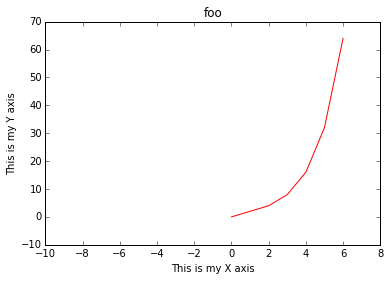

```python
x = [ 0, 1, 2, 3, 4, 5, 6 ]
y = [ 0, 2, 4, 8, 16, 32, 64 ]
plot(x, y, 'r-')
axis(xmin=-10, xmax = 8, ymin=-10)
xlabel('This is my X axis')
ylabel('This is my Y axis')
title('foo')
savefig('figure.png')
```

## ScikitLearn

- machine learning algorithms within Python code
  - classification
  - regression
  - clustering
  - preprocessing
  - ...
- clean, well-thought-out API
- built upon Python's NumPy and SciPy

### Data representation

- two-dimensional array or matrix (in most of algorithms)
- the size of the array is expected to be `[n_samples, n_features]`

### Iris

```python
from sklearn.datasets import load_iris
iris = load_iris()
iris.keys()
```

```
['target_names', 'data', 'target', 'DESCR', 'feature_names']
```

```python
n_samples, n_features = iris.data.shape
print((n_samples, n_features))
print(iris.data[0])
```

```
(150, 4)
[ 5.1  3.5  1.4  0.2]
```

```python
print(iris.data.shape)
print(iris.target.shape)
print(iris.target)
```

```
(150, 4)
(150,)
[0 0 0 0 0 0 0 0 0 0 0 0 0 0 0 0 0 0 0 0 0 0 0 0 0 0 0 0 0 0 0 0 0 0 0 0 0
 0 0 0 0 0 0 0 0 0 0 0 0 0 1 1 1 1 1 1 1 1 1 1 1 1 1 1 1 1 1 1 1 1 1 1 1 1
 1 1 1 1 1 1 1 1 1 1 1 1 1 1 1 1 1 1 1 1 1 1 1 1 1 1 2 2 2 2 2 2 2 2 2 2 2
 2 2 2 2 2 2 2 2 2 2 2 2 2 2 2 2 2 2 2 2 2 2 2 2 2 2 2 2 2 2 2 2 2 2 2 2 2
 2 2]
```

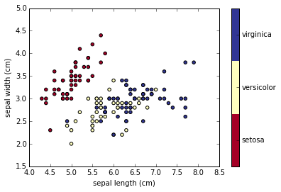

```python
x_index = 0
y_index = 1

# this formatter will label the colorbar with the correct target names
formatter = plt.FuncFormatter(lambda i, *args: iris.target_names[int(i)])

plt.scatter(iris.data[:, x_index], iris.data[:, y_index],
            c=iris.target, cmap=plt.cm.get_cmap('RdYlBu', 3))
plt.colorbar(ticks=[0, 1, 2], format=formatter)
plt.clim(-0.5, 2.5)
plt.xlabel(iris.feature_names[x_index])
plt.ylabel(iris.feature_names[y_index])
```

### Supervised Learning: Classification and Regression

```python
from sklearn import neighbors, datasets

iris = datasets.load_iris()
X, y = iris.data, iris.target

# create the model
knn = neighbors.KNeighborsClassifier(n_neighbors=5)

# fit the model
knn.fit(X, y)

# What kind of iris has 3cm x 5cm sepal and 4cm x 2cm petal?
# call the "predict" method:
result = knn.predict([[3, 5, 4, 2],])

print(iris.target_names[result])
```

```
['versicolor']
```

```python
knn.predict_proba([[3, 5, 4, 2],])
```

```
array([[ 0. ,  0.8,  0.2]])
```

```python
from sklearn.svm import SVC
```

```python
iris = datasets.load_iris()
X, y = iris.data, iris.target

model = SVC()
model.fit(X, y)
result = model.predict([[3, 5, 4, 2],])
print(iris.target_names[result])
```

```
['virginica']
```

### Clustering

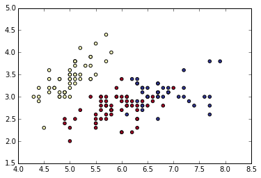

```python
from sklearn.cluster import KMeans

iris = datasets.load_iris()
X, y = iris.data, iris.target

k_means = KMeans(n_clusters=3, random_state=0) # Fixing the RNG in kmeans
k_means.fit(X)
y_pred = k_means.predict(X)

scatter(X[:, 0], X[:, 1], c=y_pred,
           cmap='RdYlBu');
```

### Model Validation

```python
from sklearn.neighbors import KNeighborsClassifier
X, y = iris.data, iris.target
clf = KNeighborsClassifier(n_neighbors=1)
clf.fit(X, y)
y_pred = clf.predict(X)
print(np.all(y == y_pred))
```

```
True
```

```python
from sklearn.metrics import confusion_matrix
print(confusion_matrix(y, y_pred))
```

```
[[50  0  0]
 [ 0 50  0]
 [ 0  0 50]]
```

```python
from sklearn.cross_validation import train_test_split
Xtrain, Xtest, ytrain, ytest = train_test_split(X, y)
clf.fit(Xtrain, ytrain)
ypred = clf.predict(Xtest)
print(confusion_matrix(ytest, ypred))
```

```
[[12  0  0]
 [ 0 13  1]
 [ 0  0 12]]
```

## Django

- web application framework
- follows MVC design pattern
- primary goal is to ease the creation of complex, database-driven websites
- emphasizes reusability and "pluggability" of components, rapid development, and the principle of DRY rule
- built-in CRUD administration panel
- well-known sites that use Django:
  - Pinterest
  - Instagram
  - Mozilla
  - Disqus

#### live demo

## Tips & Tricks - part 2

### decorators

- dynamically alter the functionality of a function, method or class without having to directly use subclasses
- work as wrappers, modifying the behavior of the code before and after a target function execution

```python
def get_text(name):
   return "lorem ipsum, {0} dolor sit amet".format(name)

def p_decorate(func):
   def func_wrapper(name):
       return "<p>{0}</p>".format(func(name))
   return func_wrapper

my_get_text = p_decorate(get_text)

print(my_get_text("John"))
```

```
<p>lorem ipsum, John dolor sit amet</p>
```

```python
@p_decorate
def get_text(name):
    return 'hello {}'.format(name)

print(get_text('Janusz'))
```

```
<p>hello Janusz</p>
```

```python
def tags(tag_name):
    def tags_decorator(func):
        def func_wrapper(name):
            return "<{0}>{1}</{0}>".format(tag_name, func(name))
        return func_wrapper
    return tags_decorator

@tags("h1")
def get_text(name):
    return "Hello "+name

print get_text("John")
```

```
<h1>Hello John</h1>
```

- można łączyć
- można przekazywać argumenty
- zarówno na metodzie, klasie jak i funkcji

### PEP8

- Style Guide for Python Code
- set of conventions
- https://www.python.org/dev/peps/pep-0008/

### Python 2 vs Python 3

- incompatible!
- Python 2.x is legacy, Python 3.x is the present and future of the language
- main problem: dependency libraries are mostly written in Python 2
- key differences:
  - print is a function
  - every string is unicode
  - integer division

### Python drawbacks

- performance
- far from the metal
- threading / GIL
- Python 2/3 separation and incompatibility

## Bonus question

#### What we've used to make this slideshow?

IPython Notebook!